# Assignment 1

```r
df <- read.csv(file="Assignment1_Data.csv")
```

### Question 1

For each of the 17 variables in the data file, indicate of what type they are and explain why. Choose from nominal scale, ordinal scale, interval scale or ratio scale.

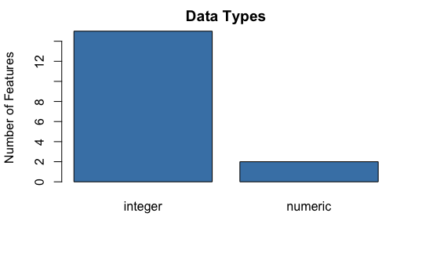

```r
data_types <- function(frame) {
  res <- lapply(frame, class)
  res_frame <- data.frame(unlist(res))
  barplot(table(res_frame), main="Data Types", col="steelblue", ylab="Number of Features")
}
data_types(df)
```

### Question 2

What is the percentage of companies that have introduced new or significantly improved products/goods?

```r
ProdInn1 <- df[(df$ProductInnovation==1),]
ProdInn0 <- df[(df$ProductInnovation==0),]

perc <- dim(ProdInn1)[1]/dim(df)[1]*100
cat(round(perc,2), "%")
```

```
30.79 %
```

### Question 3

Compare the distribution of R&D expenditures for companies that have introduced new or significantly improved products/goods, versus companies that have not. Use a plot and a statistical test. Explain which plot and test you use, and why. What do you conclude?

```r
# heavily skewed to the right
summary(ProdInn1$RDExp)
```

```
    Min.  1st Qu.   Median     Mean  3rd Qu.     Max.
  0.0000   0.0159   0.1166   2.8521   0.5600 601.9124
```

```r
summary(ProdInn0$RDExp)
```

```
   Min. 1st Qu.  Median    Mean 3rd Qu.    Max.
 0.0000  0.0000  0.0000  0.1856  0.0000 48.9588
```

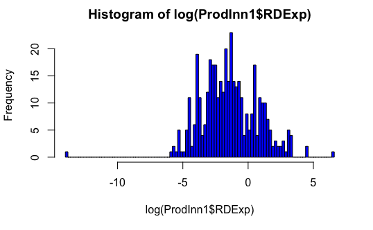

```r
# Take the log of the data so the distribution can be visualized better

hist(log(ProdInn1$RDExp), breaks=100, col='blue')
```

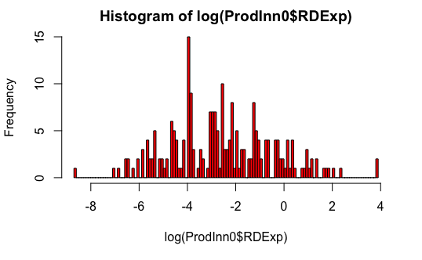

```r
hist(log(ProdInn0$RDExp), breaks=100, col='red')
```

```r
# The RDExp of companies who did innovate has a different distribution from that of those who did not innovate
ks.test(log(ProdInn1$RDExp), log(ProdInn0$RDExp))
```

```
p-value will be approximate in the presence of ties
```

```
    Two-sample Kolmogorov-Smirnov test

data:  log(ProdInn1$RDExp) and log(ProdInn0$RDExp)
D = 0.62283, p-value < 2.2e-16
alternative hypothesis: two-sided
```

### Question 4

Is manufacturing innovation (i.e., new or significantly improved manufacturing process and/or procedures for service delivery) more common for companies that have introduced new or significantly improved products/goods, versus companies that have not? Support your answer.

```r
# Manufacturing innovation is not more common for companies that innovated their products/goods, versus companies that did not
cat(dim(ProdInn1[ProdInn1$ManufacturingInnovation==1,])[1]/dim(ProdInn1)[1]*100,"% product=1, manuf=1\n")
```

```
43.76278 % product=1, manuf=1
```

```r
cat(dim(ProdInn1[ProdInn1$ManufacturingInnovation==0,])[1]/dim(ProdInn1)[1]*100,"% product=1, manuf=0\n")
```

```
56.23722 % product=1, manuf=0
```

```r
cat(dim(ProdInn0[ProdInn1$ManufacturingInnovation==1,])[1]/dim(ProdInn0)[1]*100,"% product=0, manuf=1\n")
```

```
43.49409 % product=0, manuf=1
```

```r
cat(dim(ProdInn0[ProdInn1$ManufacturingInnovation==0,])[1]/dim(ProdInn0)[1]*100,"% product=0, manuf=0\n")
```

```
56.50591 % product=0, manuf=0
```

### Question 5

Which variable(s) contain missing values?

```r
# NrEmployees has missing values
colSums(is.na(df))
```

```
                  RDExp             NrEmployees       ProductInnovation       ServiceInnovation
                      0                      32                       0                       0
ManufacturingInnovation     LogisticsInnovation       SupportInnovation                   Info1
                      0                       0                       0                       0
                  Info2                   Info3                   Info4                   Info5
                      0                       0                       0                       0
                  Info6                   Info7                   Info8                   Info9
                      0                       0                       0                       0
                 Info10
                      0
```

### Question 6

What is the percentage of missingness?

```r
cat(mean(is.na(df))*100,"% of all data points are missing.\n")
```

```
0.1185361 % of all data points are missing.
```

```r
cat(mean(is.na(df$NrEmployees))*100, "% of the NrEmployees column is missing.")
```

```
2.015113 % of the NrEmployees column is missing.
```

### Question 7

Is the missingness related to any of the other variables in the data set? Explain which tests you use and why.

```r
# Missingness is not related to any of the other variables in the dataset.
# Used 2-sample t-test to compare the mean of each variable of complete cases with that of incomplete cases

missing <- df[!complete.cases(df),]
complete <- df[complete.cases(df),]

for (i in colnames(df)){
  if(i!="NrEmployees"){
    print(i)
    print(t.test(missing[[i]],complete[[i]])$p.value)
  }
}
```

```
[1] "RDExp"
[1] 0.6726919
[1] "ProductInnovation"
[1] 0.2678342
[1] "ServiceInnovation"
[1] 0.4889777
[1] "ManufacturingInnovation"
[1] 0.5190819
[1] "LogisticsInnovation"
[1] 0.528004
[1] "SupportInnovation"
[1] 0.8446386
[1] "Info1"
[1] 0.7237841
[1] "Info2"
```

[output cut: 17 more lines]

### Question 8

What do you conclude about the type of missingness from your tests of the previous question?

I conclude that the data is missing at random and can be omitted from the dataset.

### Question 9

Compute the Mahalanobis distances of the companies based on the information variables. Graphically present the Mahalanobis distances.

```r
complete
```

[output not shown]

[output cut: 990 more lines]

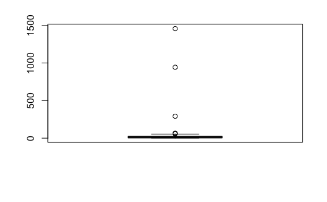

```r
maha_distance <- complete[,c(8:17)]
dist <- mahalanobis(complete, center=colMeans(complete), cov=cov(complete))
maha_distance$dist <- round(dist, 2)

maha_distance$outlier_maha <- 0
maha_distance$outlier_maha[maha_distance$dist > 3] <- 1

upper.whisker <- boxplot(maha_distance$dist)$stats[5]
```

### Question 10

Can we use the rule-of-thumb that observations of which the Mahalanobis Distance divided q is larger 3 are outliers? Here, q is the number of variables used in the calculation of the Mahalanobis distance. Explain why or why not.

```r
# Do not use 3 as the rule of thumb because the data is not normally distributed.
mean(maha_distance$outlier_maha)
```

```
[1] 0.6735219
```

### Question 11

Which companies, if any, are outliers? Describe the decision process by which you have or have not identified outliers. If you have identified outliers, perform the rest of the assignment after dropping the outliers from the analysis.

```r
# only 6 outliers when using the upper whisker as the threshold (54.57)
outliers <- complete[maha_distance$dist>upper.whisker,]
no_outliers <- complete[maha_distance$dist<=upper.whisker,]
outliers
```

|  | RDExp | NrEmployees | ProductInnovation | ServiceInnovation | ManufacturingInnovation | LogisticsInnovation | SupportInnovation | Info1 | Info2 | Info3 | Info4 | Info5 | Info6 | Info7 | Info8 | Info9 | Info10 |
| --- | --- | --- | --- | --- | --- | --- | --- | --- | --- | --- | --- | --- | --- | --- | --- | --- | --- |
| 656 | 0.000000 | 3840.820 | 0 | 1 | 1 | 1 | 1 | 3 | 2 | 3 | 3 | 0 | 0 | 0 | 2 | 1 | 3 |
| 675 | 0.000000 | 3773.849 | 0 | 1 | 1 | 1 | 1 | 3 | 2 | 3 | 3 | 0 | 0 | 0 | 2 | 1 | 3 |
| 1054 | 601.912415 | 50383.152 | 1 | 1 | 1 | 1 | 0 | 3 | 3 | 3 | 2 | 1 | 1 | 1 | 2 | 2 | 2 |
| 1176 | 2.490744 | 20370.178 | 0 | 0 | 1 | 0 | 0 | 2 | 1 | 1 | 2 | 3 | 2 | 1 | 3 | 1 | 0 |
| 1307 | 0.000000 | 4544.070 | 0 | 1 | 1 | 1 | 1 | 2 | 3 | 1 | 2 | 3 | 1 | 1 | 2 | 2 | 2 |
| 1370 | 0.000000 | 10849.433 | 1 | 0 | 1 | 1 | 0 | 3 | 2 | 3 | 3 | 0 | 2 | 1 | 1 | 1 | 0 |

### Question 12

Is a factor analysis appropriate for the questions on the information sources of innovations? Explain how you have checked whether factor analysis is appropriate.

Yes, factor analysis is appropriate because there exists a positive correlation (greater than .5 even) between several of the variables.

```r
library(psych)
library(ggplot2)
# make heatmap
cormat <- round(cor(no_outliers[,c(8:17)]),2)
cormat
```

```
       Info1 Info2 Info3 Info4 Info5 Info6 Info7 Info8 Info9 Info10
Info1   1.00  0.65  0.75  0.66  0.39  0.50  0.38  0.63  0.63   0.45
Info2   0.65  1.00  0.59  0.60  0.45  0.36  0.30  0.60  0.58   0.47
Info3   0.75  0.59  1.00  0.68  0.42  0.47  0.37  0.65  0.60   0.41
Info4   0.66  0.60  0.68  1.00  0.36  0.44  0.35  0.65  0.61   0.51
Info5   0.39  0.45  0.42  0.36  1.00  0.37  0.30  0.41  0.38   0.28
Info6   0.50  0.36  0.47  0.44  0.37  1.00  0.71  0.49  0.54   0.38
Info7   0.38  0.30  0.37  0.35  0.30  0.71  1.00  0.43  0.48   0.42
Info8   0.63  0.60  0.65  0.65  0.41  0.49  0.43  1.00  0.73   0.52
Info9   0.63  0.58  0.60  0.61  0.38  0.54  0.48  0.73  1.00   0.59
Info10  0.45  0.47  0.41  0.51  0.28  0.38  0.42  0.52  0.59   1.00
```

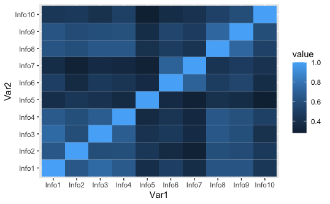

```r
melted_cormat <- reshape2::melt(cormat)

ggplot(data = melted_cormat, aes(x=Var1, y=Var2, fill=value)) +
  geom_tile()
```

### Question 13

Make a scree plot. How many factors does the scree plot suggest?

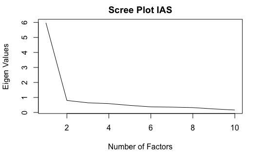

```r
# 2 factors
EigenDecomp <- eigen(cov(no_outliers[,c(8:17)]))
EigenValues <- EigenDecomp$values
plot(EigenValues,main="Scree Plot IAS",type="l", xlab="Number of Factors",ylab="Eigen Values")
```

### Question 14

For what purpose is a rotation of the factors in an exploratory factor analysis used? Should we perform a rotation in this setting? Why or why not?

Rotate so that the factor loadings are easier to interpret. For example, consider 2 factor loadings F1 and F2 with variables X1 and X2 in a cluster with higher loadings for F1 and X3 and X4 with higher loadings for F2. When we perform a varimax rotation, we will create new factor loadings that give variables X1 and X2 high values for F1 and low for F2, and vice versa for variables X3 and X4.

### Question 15

Perform factor analysis using the number of factors as suggested by the scree plot. Clearly state how many factors you have included and whether or not you have used a rotation. Report the estimated uniquenesses and factor loadings.

I am including all 10 information variables and am using rotation. The algroithm has converged. Two factors are not sufficent because Chi-squared null hypotheses is rejected.

```r
# Two factors are not sufficent. Chi squared null hypotheses is rejected.
k<-2
EFA.kfactors <- factanal(no_outliers[,c(8:17)], factors=k, rotation="varimax")
EFA.kfactors$converged
```

```
[1] TRUE
```

```r
EFA.kfactors
```

```
Call:
factanal(x = no_outliers[, c(8:17)], factors = k, rotation = "varimax")

Uniquenesses:
 Info1  Info2  Info3  Info4  Info5  Info6  Info7  Info8  Info9 Info10
 0.305  0.427  0.324  0.357  0.743  0.352  0.186  0.342  0.353  0.619

Loadings:
       Factor1 Factor2
Info1  0.792   0.260
Info2  0.737   0.174
Info3  0.785   0.243
Info4  0.767   0.232
Info5  0.443   0.246
Info6  0.360   0.720
Info7  0.192   0.882
Info8  0.741   0.329
Info9  0.698   0.399
Info10 0.507   0.352

               Factor1 Factor2
SS loadings      4.032   1.958
Proportion Var   0.403   0.196
Cumulative Var   0.403   0.599

Test of the hypothesis that 2 factors are sufficient.
The chi square statistic is 475.22 on 26 degrees of freedom.
The p-value is 4.57e-84
```